# Analyse des groupes

## Objectif du document

Le but est de décrire les groupes de bateaux obtenus par colSBM (cf. papier JRSS C), en terme de zones de pêche, ciblage d’espèce, caractéristique des bateaux…

```r
#|>echo: False

library(tidyverse)
library(lubridate)
df_cvae_group <- read_csv(file = "../Rdata/xgv_cvae_group.csv")
df_sacrois_xgv_capt <- read_csv("../Rdata/sacrois_xgv_capt_complet.csv")
df_traj <- lapply(
  c("2014", "2015", "2016", "2017", "2018"),
  function(year) {
    df_tmp <-  read_delim(paste0("../data/Geoloc/SIH-GEOLOC-positions-macco-", year, ".csv"),
                          delim = ";",
                          col_types = cols(
                            ID = col_skip(), #col_integer(),
                            NAVIRE = col_integer(),
                            PAVILLON = col_skip(),#col_factor(),
                            DATE_HEURE = col_datetime("%d/%m/%Y %H:%M:%S"),
                            LONGITUDE = col_double(),
                            LATITUDE = col_double(),
                            VITESSE_MOYENNE = col_skip(), #col_double(),
                            VITESSE_INSTANTANEE = col_skip(), #col_double(),
                            DIRECTION = col_double(),
                            EN_PECHE = col_logical(),
                            ENGF_COD_PRINC = col_skip(), #col_factor(),
                            ENGF_LIB_PRINC = col_skip(), #col_character(),
                            S_FLOTTILLE_IFREMER_COD = col_skip(), #col_factor(),
                            S_FLOTTILLE_IFREMER_LIB = col_skip(), #col_character(),
                            TAILLE = col_double(),
                            PUISSANCE = col_double(),
                            MAREE_ID = col_integer()
                          ))
    df_tmp |>
      filter(MAREE_ID %in% df_cvae_group$maree,
             EN_PECHE == TRUE) |>
      select(-EN_PECHE)
  }
)
```

```r
#|>echo: False

df_traj_group <- bind_rows(df_traj) |> rename(maree=MAREE_ID) |>
  left_join(df_cvae_group) |>
  select(navire, maree, LONGITUDE, LATITUDE, TAILLE, PUISSANCE, time, Group)
```

## Zones de pêche

Les zones de pêche des groupes ne se recouvrent que partiellement.

[figure not shown]

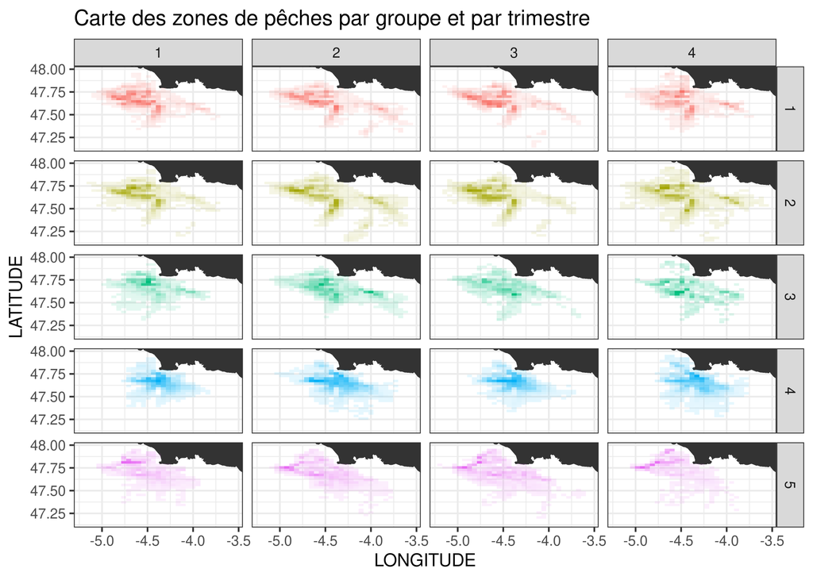

```r
df_traj_group |> mutate(quarter = quarter(time)) |>
  #filter(quarter == 2) |>
  ggplot(aes(x = LONGITUDE, y = LATITUDE, fill = as_factor(Group))) +
  annotation_map(map = fortify(maps::map("france", xlim = c(-5.3, -3.6), ylim = c(47, 48.3)))) +
  stat_bin_2d(aes(alpha = after_stat(ndensity)), show.legend = FALSE) +
#  geom_hex() +
  coord_fixed() +
  facet_grid(Group ~ quarter) +
  theme_bw() +
  ggtitle("Carte des zones de pêches par groupe et par trimestre")
```

## Caratéristiques des navires de pêche

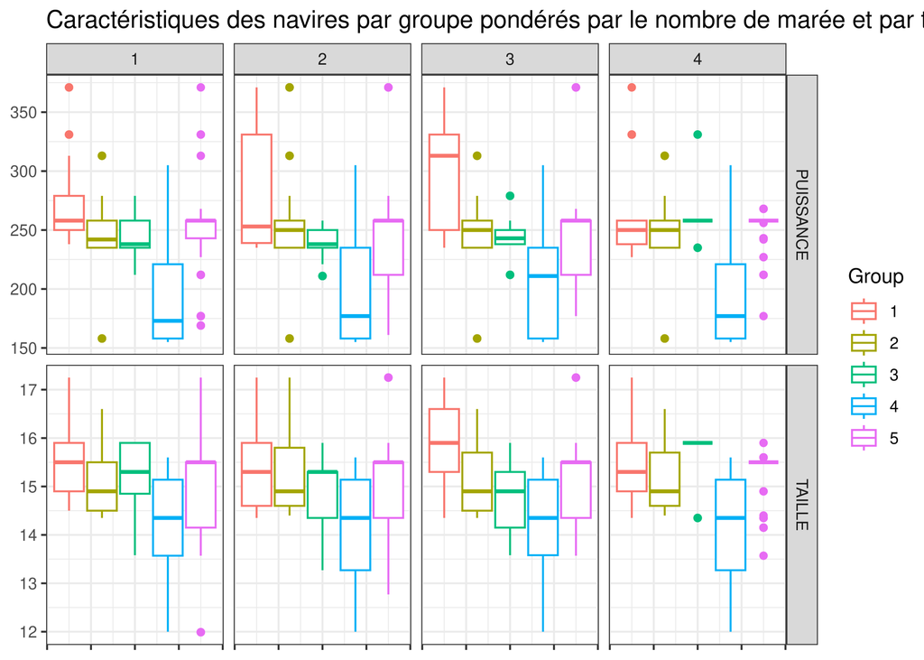

```r
df_traj_group |> mutate(quarter = quarter(time)) |>
  mutate(year = year(time)) |>
  select(-LATITUDE, -LONGITUDE) |>
  distinct() |>
  mutate(Group = as_factor(Group)) |>
  pivot_longer(cols = c(TAILLE, PUISSANCE)) |>
  ggplot(aes(y = value,  col = Group)) +
  geom_boxplot() +
  labs(x = NULL, y=NULL) +
#  geom_point() +
#  geom_errorbar(aes(ymin=numeric.mean-numeric.sd, ymax=numeric.mean+numeric.sd), width=.2,
#                position=position_dodge(0.1)) +
#  geom_line(linewidth = .1) +
  facet_grid(name ~quarter, scales = "free_y") +
  theme_bw() +
  theme(axis.text.x = element_blank()) +
  ggtitle("Caractéristiques des navires par groupe pondérés par le nombre de marée et par trimestre")
```

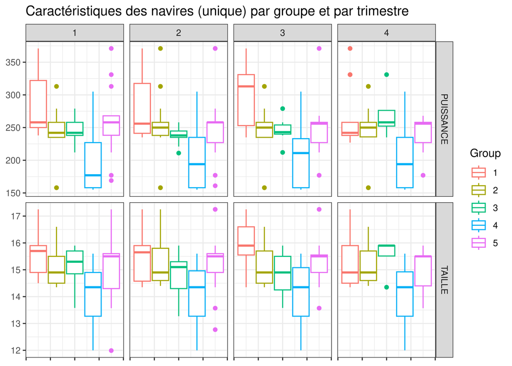

```r
df_traj_group |> mutate(quarter = quarter(time)) |>
  mutate(year = year(time)) |>
  select(-LATITUDE, -LONGITUDE) |>
  distinct() |>
  mutate(Group = as_factor(Group)) |>
  group_by(Group, quarter, year) |>
  distinct(navire, TAILLE, PUISSANCE) |>
  pivot_longer(cols = c(TAILLE, PUISSANCE)) |>
  ggplot(aes(y = value,  col = Group)) +
  geom_boxplot() +
  labs(x = NULL, y = NULL) +
  #  geom_point() +
  #  geom_errorbar(aes(ymin=numeric.mean-numeric.sd, ymax=numeric.mean+numeric.sd), width=.2,
  #                position=position_dodge(0.1)) +
  #  geom_line(linewidth = .1) +
  facet_grid(name ~quarter, scales = "free_y") +
  theme_bw()+
  theme(axis.text.x = element_blank()) +
  ggtitle("Caractéristiques des navires (unique) par groupe et par trimestre")
```

## Ciblage des espèces

Ici, on regarde l’importance économique de chaque espèce pour chaque groupe. La langoustine (NEP) représente la majeure partie de l’économie de la flottille, en particulier en second trimestre (trimestre de référence WGBIE). Le groupe $E$ se distingue. En particulier, la longoustine est très minoritaire au trimestre $1$ et $4$. La sole est bien réparti entre les groupes en valeur relative. On remarque une différence dans l’importance de la baudroie (HKE) et de la cardine (MNZ) entre les groupes $D$, $E$ et $A$, $B$, $C$.

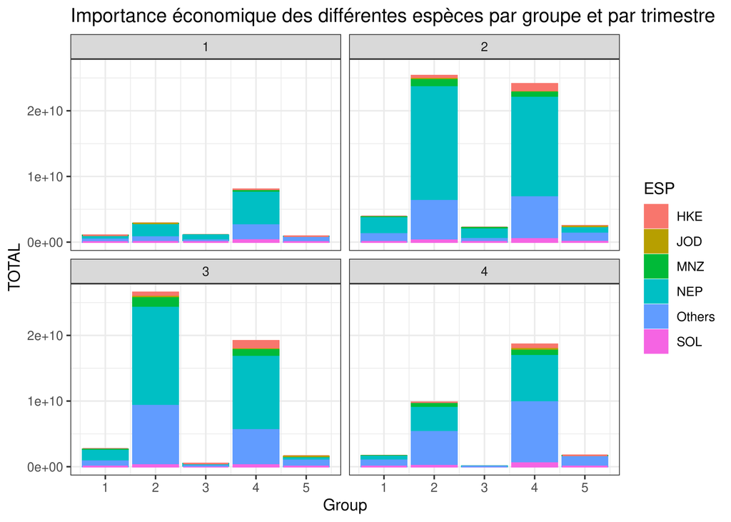

```r
df_sacrois_xgv_capt %>%
  filter(MONTANT_EUROS_MOYENNE < 8000) |>
#  mutate(MONTANT_EUROS_MOYENNE = pmin(MONTANT_EUROS_MOYENNE, 8000)) %>%
  rename(maree = MAREE_ID) %>%
  left_join(df_cvae_group) %>%
  mutate(year = year(time),
         quarter = quarter(time)) |>
  mutate(ESP = case_match(ESP_COD_FAO,
                                 "HKE" ~ ESP_COD_FAO,
                                 "SOL" ~ ESP_COD_FAO,
                                 "JOD" ~ ESP_COD_FAO,
                                 "NEP" ~ ESP_COD_FAO,
                                 "MNZ" ~ ESP_COD_FAO,
                                 .default = "Others")) |>
  group_by(Group, quarter, ESP) |>
  select(MONTANT_EUROS_MOYENNE) |>
  mutate(TOTAL = sum(MONTANT_EUROS_MOYENNE)) |>
  ggplot(aes(x = Group, y = TOTAL, fill = ESP, col = ESP)) +
  geom_col() +
  facet_wrap(~ quarter) +
  theme_bw()+
  ggtitle("Importance économique des différentes espèces par groupe et par trimestre")
```

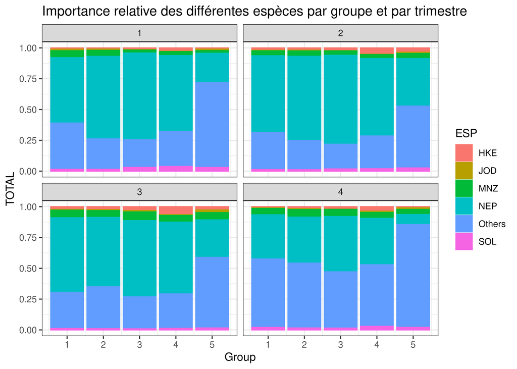

```r
df_sacrois_xgv_capt %>%
  filter(MONTANT_EUROS_MOYENNE < 8000) |>
#  mutate(MONTANT_EUROS_MOYENNE = pmin(MONTANT_EUROS_MOYENNE, 8000)) %>%
  rename(maree = MAREE_ID) %>%
  left_join(df_cvae_group) %>%
  mutate(year = year(time),
         quarter = quarter(time)) |>
  mutate(ESP = case_match(ESP_COD_FAO,
                                 "HKE" ~ ESP_COD_FAO,
                                 "SOL" ~ ESP_COD_FAO,
                                 "JOD" ~ ESP_COD_FAO,
                                 "NEP" ~ ESP_COD_FAO,
                                 "MNZ" ~ ESP_COD_FAO,
                                 .default = "Others")) |>
  group_by(Group, quarter, ESP) |>
  select(MONTANT_EUROS_MOYENNE) |>
  mutate(TOTAL = sum(MONTANT_EUROS_MOYENNE)) |>
  ggplot(aes(x = Group, y = TOTAL, fill = ESP, col = ESP)) +
  geom_col(position = "fill") +
  facet_wrap(~ quarter) +
  theme_bw()+
  ggtitle("Importance relative des différentes espèces par groupe et par trimestre")
```

## Intégration des groupes dans les calculs des LPUE

Au niveau d’un trimestre (pour chaque année), un groupe est composé de navires ayant les mêmes similarité de comportement, en terme de trajectoires, par rapport au navire d’un autre groupe. C’est différent que de dire que chaque navire d’un groupe à le même comportement.

Nous proposons pour chaque jour de marée, un indice pondéré composé d’un effort individuel (au niveau du navire) et un effort collectif (au niveau du groupe).

Soit $E_{g,d} = \frac{1}{|b\in g|}\sum_{b\in g}E_{b,d}$, l’effort collectif moyen du groupe $g$ pour le jour $d$. On calcul de la même manière les débarquements de groupes. Le modèle colSBM nous permet d’obtenir des proportions de connexions entre groupes (noté $\alpha$). On obtient ainsi pour chaque bateau un Effort modifié par l’effort collectif. Soit $LPUE_{g,d} = C_{g,d}/E_{g,d}$, alors pour $b \in g$,
$$NLPUE_{b,d} = \frac{1}{|G|}\sum_{h \in G} \alpha_{gh}\frac{C_{b,d}}{E_{h,d}} + (1-\alpha_{gh})LPUE_{b,d}$$

On peut ensuite pondérer chaque navire en fonction de l’effectif de chaque groupe pour calculer les LPUE de la flotte:
$$NLPUE_{d} = \frac{1}{G}\sum_{g}\frac{1}{|b\in g|}\sum_{b}NLPUE_{b,d}$$

Cela permet de réduire le poids dans le calcul des navires effectuant le même type de trajectoire, et ainsi donner plus d’importance à ceux ayant des trajectoires isolés.

## Calcul des LPUE relatives

Nous calculons pour 4 types d’espèce (NEP, SOL, HKE, MNZ), les LPUE via trois méthodes :

- La méthode naive, où chaque marée à le même poids
- La méthode avec les effort normalisées de chaque marée
- La méthode avec les effort normalisées de chaque marée et la pondération par groupe.

### Les langoustines

```r
iidcolsbm_trim <- readRDS("../Rdata/save_sbmfit/iidcolsbm_trim.rds")
alpha <- iidcolsbm_trim$alpha
```

```r
df_nep <- df_sacrois_xgv_capt |> filter(ESP_COD_FAO == "NEP") |>
  select(TP_NAVIRE_SACROIS, MAREE_ID, QUANT_POIDS_VIF_MOYENNE) |>
  group_by(MAREE_ID) |>
  summarise(LANDINGS = sum(QUANT_POIDS_VIF_MOYENNE),
            EFFORT = sum(TP_NAVIRE_SACROIS)) |>
  ungroup()
df_nep <-
  df_nep |>
  rename(maree = MAREE_ID) |>
  left_join(df_cvae_group) |>
  mutate(year = factor(year(time)),
         Group = LETTERS[Group]) |>
  mutate(Group = factor(Group, levels = LETTERS[1:5])) |>
  na.omit() |>
  filter(LANDINGS <= 1000) |>
  select(maree, time, navire, LANDINGS, EFFORT, Group)
```

On calcule juste les LPUE au second trimestre, ce qui correspond au trimestre de référence du WGBIE

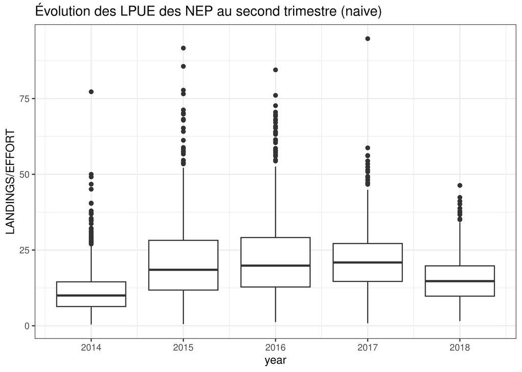

```r
df_nep |>
  mutate(quarter = quarter(time), year = year(time)) |>
  filter(EFFORT >= 3) |>
  filter(quarter == 2) |>
  ggplot(aes(x = year, y = LANDINGS/EFFORT, group = year)) +
  geom_boxplot() +
  theme_bw() +
  ggtitle("Évolution des LPUE des NEP au second trimestre (naive)")
```

Les évolutions relatives de la médiane sont de :

```r
df_nep |>
  mutate(quarter = quarter(time), year = year(time)) |>
  filter(EFFORT >= 3) |>
  filter(quarter == 2) |>
  mutate(LPUE = LANDINGS/EFFORT) |>
  group_by(quarter, year) |>
  summarise(LPUE = median(LPUE)) |>
  mutate(REL_LPUE = LPUE/min(LPUE))
```

```
# A tibble: 5 × 4
# Groups:   quarter [1]
  quarter  year  LPUE REL_LPUE
    <int> <dbl> <dbl>    <dbl>
1       2  2014  10.0     1
2       2  2015  18.5     1.85
3       2  2016  19.9     1.99
4       2  2017  20.9     2.09
5       2  2018  14.7     1.47
```

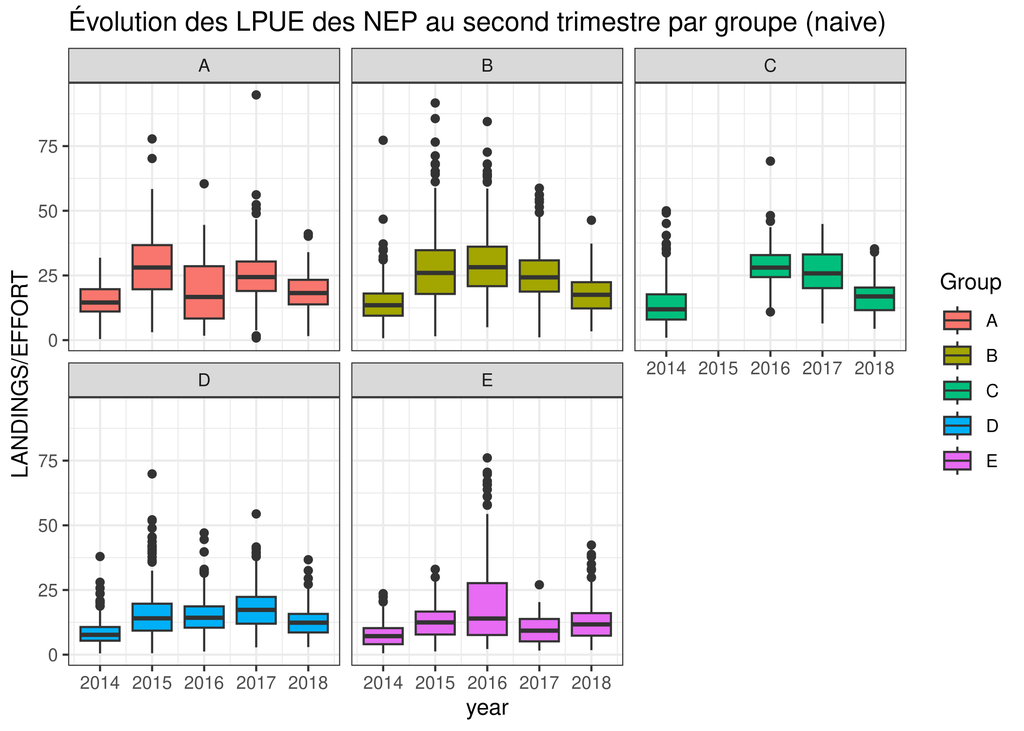

```r
df_nep |>
  mutate(quarter = quarter(time), year = year(time)) |>
  filter(EFFORT >= 3) |>
  filter(quarter == 2) |>
  ggplot(aes(x = year, y = LANDINGS/EFFORT, group = year, fill = Group)) +
  geom_boxplot() +
  theme_bw() +
  facet_wrap(~ Group) +
  ggtitle("Évolution des LPUE des NEP au second trimestre par groupe (naive)")
```

```r
group_effort <- df_nep |>
  group_by(Group, time) |>
  filter(quarter(time) == 2) |>
  summarise(EFFORT = mean(EFFORT))
unique_navire <- df_nep |> filter(quarter(time) == 2) |> pull(navire) |> unique()
unique_date <- df_nep |> filter(quarter(time) == 2) |> pull(time) |> unique()
unique_group <- df_nep |> filter(quarter(time) == 2) |> pull(Group) |> unique()
maree <- df_nep |> filter(quarter(time) == 2) |> pull(maree) |> unique()
indiv_effort <-
  df_nep |>
  filter(quarter(time) == 2)
norm_indiv_effort <-
 sapply(seq_along(maree),
       function(m) {
         df <- indiv_effort[m,]
         geff <- group_effort |> filter(time == df$time)
         mean(geff$EFFORT*iidcolsbm_trim$alpha[df$Group, geff$Group] +
           (1-iidcolsbm_trim$alpha[df$Group, geff$Group])*df$EFFORT)
       })
```

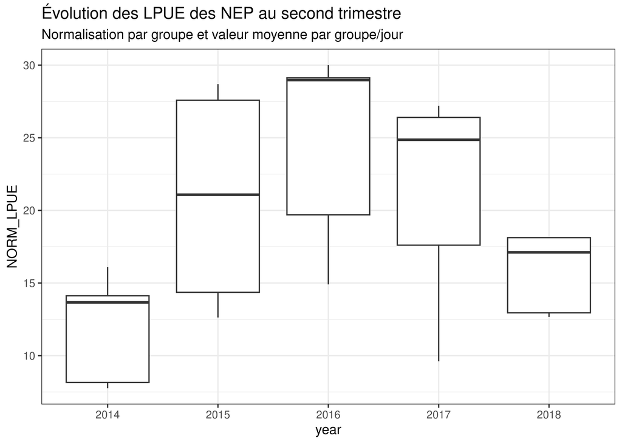

```r
indiv_effort |> ungroup() |>
  mutate(NORM_EFFORT = norm_indiv_effort) |>
  mutate(year = factor(year(time))) |>
  mutate(NORM_LPUE = LANDINGS/NORM_EFFORT) |>
  group_by(Group, year) |>
  summarise(NORM_LPUE = mean(NORM_LPUE)) |>
  ggplot(aes(x = year, y = NORM_LPUE)) +
  geom_boxplot() +
  theme_bw() +
  ggtitle("Évolution des LPUE des NEP au second trimestre",
          subtitle = "Normalisation par groupe et valeur moyenne par groupe/jour")
```

Les évolutions relatives de la médiane sont de :

```r
indiv_effort |> ungroup() |>
  mutate(NORM_EFFORT = norm_indiv_effort) |>
  mutate(year = factor(year(time))) |>
  mutate(NORM_LPUE = LANDINGS/NORM_EFFORT) |>
  group_by(Group, year) |>
  summarise(NORM_LPUE = mean(NORM_LPUE)) |>
  ungroup() |>
  group_by(year) |>
  summarise(NORM_LPUE = median(NORM_LPUE)) |>
  mutate(NORM_LPUE = NORM_LPUE/min(NORM_LPUE))
```

```
# A tibble: 5 × 2
  year  NORM_LPUE
  <fct>     <dbl>
1 2014       1
2 2015       1.54
3 2016       2.12
4 2017       1.82
5 2018       1.25
```

### La sole

!!! Attention !!! : Changement législatif en 2015 sur la taille des captures

```r
df_sol <- df_sacrois_xgv_capt |> filter(ESP_COD_FAO == "SOL") |>
  select(TP_NAVIRE_SACROIS, MAREE_ID, QUANT_POIDS_VIF_MOYENNE) |>
  group_by(MAREE_ID) |>
  summarise(LANDINGS = sum(QUANT_POIDS_VIF_MOYENNE),
            EFFORT = sum(TP_NAVIRE_SACROIS)) |>
  ungroup() |>
  rename(maree = MAREE_ID) |>
  left_join(df_cvae_group) |>
  mutate(year = factor(year(time)),
         Group = LETTERS[Group]) |>
  mutate(Group = factor(Group, levels = LETTERS[1:5])) |>
  na.omit() |>
  select(maree, time, navire, LANDINGS, EFFORT, Group)
```

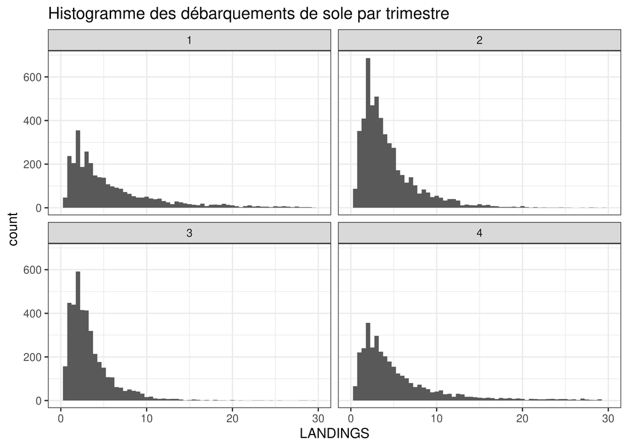

```r
df_sol |>
  mutate(quarter = quarter(time)) |>
  ggplot(aes(x = LANDINGS)) +
  geom_histogram(binwidth = .5) +
  theme_bw() +
  facet_wrap(~ quarter) +
  xlim(0,30) +
  ggtitle("Histogramme des débarquements de sole par trimestre")
```

Vu le nombre de débarquements inférieur à 2kg, on peut s’intérroger à mettre un filtre sur le poids de débarquement minimal.

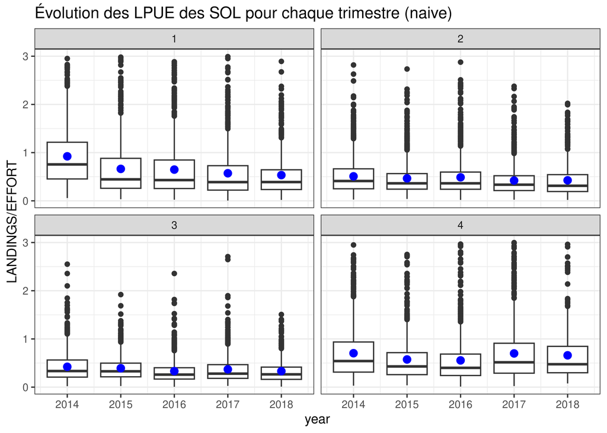

```r
df_sol |>
  mutate(quarter = quarter(time), year = year(time)) |>
  filter(EFFORT >= 3) |>
#  filter(quarter == 2) |>
  ggplot(aes(x = year, y = LANDINGS/EFFORT, group = year)) +
  geom_boxplot() +
  stat_summary(col = "blue") +
  theme_bw() +
  facet_wrap(~ quarter) +
  ylim(0,3) +
  ggtitle("Évolution des LPUE des SOL pour chaque trimestre (naive)")
```

Les évolutions relatives de la médiane sont de :

```r
df_sol |>
  mutate(quarter = quarter(time), year = year(time)) |>
  filter(EFFORT >= 3) |>
#  filter(quarter == 2) |>
  mutate(LPUE = LANDINGS/EFFORT) |>
  group_by(quarter, year) |>
  summarise(LPUE = median(LPUE)) |>
  mutate(REL_LPUE = LPUE/LPUE[1])
```

```
# A tibble: 20 × 4
# Groups:   quarter [4]
   quarter  year  LPUE REL_LPUE
     <int> <dbl> <dbl>    <dbl>
 1       1  2014 0.784    1
 2       1  2015 0.462    0.589
 3       1  2016 0.439    0.560
 4       1  2017 0.392    0.500
 5       1  2018 0.391    0.499
 6       2  2014 0.412    1
 7       2  2015 0.364    0.882
 8       2  2016 0.364    0.883
 9       2  2017 0.336    0.814
10       2  2018 0.312    0.757
11       3  2014 0.335    1
12       3  2015 0.329    0.983
13       3  2016 0.260    0.778
14       3  2017 0.282    0.844
15       3  2018 0.266    0.793
16       4  2014 0.577    1
17       4  2015 0.431    0.747
18       4  2016 0.404    0.700
19       4  2017 0.528    0.914
20       4  2018 0.486    0.841
```

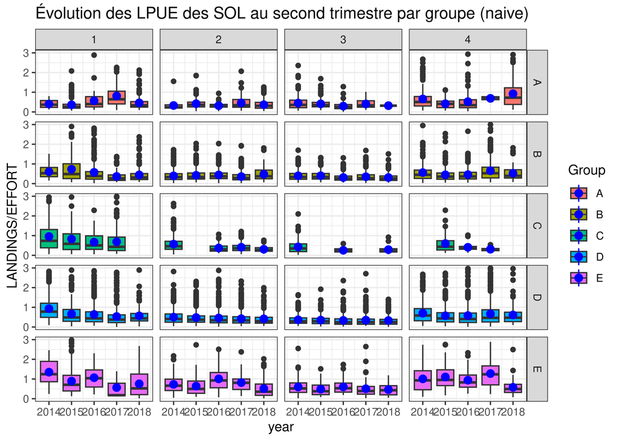

```r
df_sol |>
  mutate(quarter = quarter(time), year = year(time)) |>
  filter(EFFORT >= 3) |>
 # filter(quarter == 2) |>
  ggplot(aes(x = year, y = LANDINGS/EFFORT, group = year, fill = Group)) +
  geom_boxplot() +
  theme_bw() +
  stat_summary(col = "blue", fun = "mean") +
  facet_grid(Group ~ quarter) +
  ylim(0,3) +
  ggtitle("Évolution des LPUE des SOL au second trimestre par groupe (naive)")
```

On se concentre sur le premier trimestre pour l’évaluation des LPUE avec effort normalisé.

```r
group_effort <- df_sol |>
  group_by(Group, time) |>
  filter(quarter(time) == 1) |>
  summarise(EFFORT = mean(EFFORT))
unique_navire <- df_sol |> filter(quarter(time) == 1) |> pull(navire) |> unique()
unique_date <- df_sol |> filter(quarter(time) == 1) |> pull(time) |> unique()
unique_group <- df_sol |> filter(quarter(time) == 1) |> pull(Group) |> unique()
maree <- df_sol |> filter(quarter(time) == 1) |> pull(maree) |> unique()
indiv_effort <-
  df_sol |>
  filter(quarter(time) == 1)
norm_indiv_effort <-
 sapply(seq_along(maree),
       function(m) {
         df <- indiv_effort[m,]
         geff <- group_effort |> filter(time == df$time)
         mean(geff$EFFORT*iidcolsbm_trim$alpha[df$Group, geff$Group] +
           (1-iidcolsbm_trim$alpha[df$Group, geff$Group])*df$EFFORT)
       })
```

[figure not shown]

```r
indiv_effort |> ungroup() |>
  mutate(NORM_EFFORT = norm_indiv_effort) |>
  mutate(year = factor(year(time))) |>
  mutate(NORM_LPUE = LANDINGS/NORM_EFFORT) |>
  group_by(Group, year) |>
  summarise(NORM_LPUE = mean(NORM_LPUE)) |>
  ggplot(aes(x = year, y = NORM_LPUE)) +
  geom_boxplot() +
  theme_bw() +
  ggtitle("Évolution des LPUE des SOL au second trimestre",
          subtitle = "Normalisation par groupe et valeur moyenne par groupe/jour")
```

Les évolutions relatives de la médiane sont de :

```r
indiv_effort |> ungroup() |>
  mutate(NORM_EFFORT = norm_indiv_effort) |>
  mutate(year = factor(year(time))) |>
  mutate(NORM_LPUE = LANDINGS/NORM_EFFORT) |>
  group_by(Group, year) |>
  summarise(NORM_LPUE = mean(NORM_LPUE)) |>
  ungroup() |>
  group_by(year) |>
  summarise(NORM_LPUE = median(NORM_LPUE)) |>
  mutate(NORM_LPUE = NORM_LPUE/NORM_LPUE[1])
```

```
# A tibble: 5 × 2
  year  NORM_LPUE
  <fct>     <dbl>
1 2014      1
2 2015      0.821
3 2016      0.661
4 2017      0.568
5 2018      0.521
```

### La baudroie

```r
df_hke <- df_sacrois_xgv_capt |> filter(ESP_COD_FAO == "HKE") |>
  select(TP_NAVIRE_SACROIS, MAREE_ID, QUANT_POIDS_VIF_MOYENNE) |>
  group_by(MAREE_ID) |>
  summarise(LANDINGS = sum(QUANT_POIDS_VIF_MOYENNE),
            EFFORT = sum(TP_NAVIRE_SACROIS)) |>
  ungroup() |>
  rename(maree = MAREE_ID) |>
  left_join(df_cvae_group) |>
  mutate(year = factor(year(time)),
         Group = LETTERS[Group]) |>
  mutate(Group = factor(Group, levels = LETTERS[1:5])) |>
  na.omit() |>
  select(maree, time, navire, LANDINGS, EFFORT, Group)
```

[figure not shown]

```r
df_hke |>
  mutate(quarter = quarter(time)) |>
  ggplot(aes(x = LANDINGS)) +
  geom_histogram(binwidth = .5) +
  theme_bw() +
  facet_wrap(~ quarter) +
  xlim(0,100) +
  ggtitle("Histogramme des débarquements de sole par trimestre")
```

Vu le nombre de débarquements inférieur à 2kg, on peut s’intérroger à mettre un filtre sur le poids de débarquement minimal.

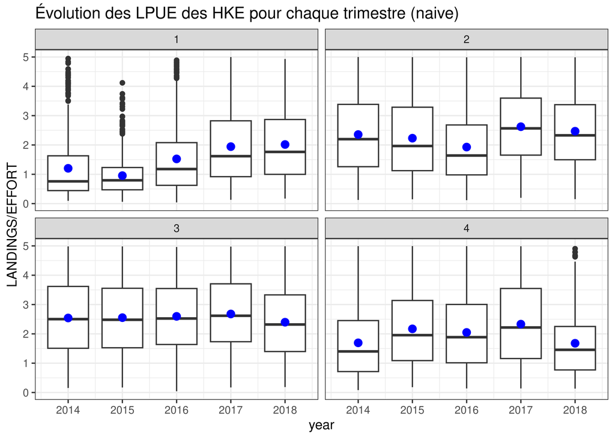

```r
df_hke |>
  mutate(quarter = quarter(time), year = year(time)) |>
  filter(EFFORT >= 3) |>
#  filter(quarter == 2) |>
  ggplot(aes(x = year, y = LANDINGS/EFFORT, group = year)) +
  geom_boxplot() +
  stat_summary(col = "blue") +
  theme_bw() +
  facet_wrap(~ quarter) +
  ylim(0,5) +
  ggtitle("Évolution des LPUE des HKE pour chaque trimestre (naive)")
```

Les évolutions relatives de la médiane sont de :

```r
df_hke |>
  mutate(quarter = quarter(time), year = year(time)) |>
  filter(EFFORT >= 3) |>
#  filter(quarter == 2) |>
  mutate(LPUE = LANDINGS/EFFORT) |>
  group_by(quarter, year) |>
  summarise(LPUE = median(LPUE)) |>
  mutate(REL_LPUE = LPUE/LPUE[1])
```

```
# A tibble: 20 × 4
# Groups:   quarter [4]
   quarter  year  LPUE REL_LPUE
     <int> <dbl> <dbl>    <dbl>
 1       1  2014 0.836    1
 2       1  2015 0.796    0.951
 3       1  2016 1.22     1.46
 4       1  2017 1.85     2.21
 5       1  2018 2.03     2.42
 6       2  2014 3.31     1
 7       2  2015 3.08     0.931
 8       2  2016 2.19     0.661
 9       2  2017 3.18     0.960
10       2  2018 2.82     0.852
11       3  2014 3.49     1
12       3  2015 4.01     1.15
13       3  2016 2.91     0.834
14       3  2017 3.94     1.13
15       3  2018 3.24     0.927
16       4  2014 1.63     1
17       4  2015 2.78     1.70
18       4  2016 2.25     1.38
19       4  2017 3.11     1.90
20       4  2018 1.69     1.03
```

[figure not shown]

```r
df_hke |>
  mutate(quarter = quarter(time), year = year(time)) |>
  filter(EFFORT >= 3) |>
 # filter(quarter == 2) |>
  ggplot(aes(x = year, y = LANDINGS/EFFORT, group = year, fill = Group)) +
  geom_boxplot() +
  theme_bw() +
  stat_summary(col = "blue", fun = "mean") +
  facet_grid(Group ~ quarter) +
  ylim(0,5) +
  ggtitle("Évolution des LPUE des SOL au second trimestre par groupe (naive)")
```

On se concentre sur le quatrième trimestre pour l’évaluation des LPUE avec effort normalisé. C’est un bon exemple pour évaluer le changement de la méthode de calcul car les deux groupes principaux (B et D) sont quasiment stable alors que les petits groupes $A$ et $E$ ont des variabilités pas au même moment.

```r
group_effort <- df_hke |>
  group_by(Group, time) |>
  filter(quarter(time) == 4) |>
  summarise(EFFORT = mean(EFFORT))
unique_navire <- df_hke |> filter(quarter(time) == 4) |> pull(navire) |> unique()
unique_date <- df_hke |> filter(quarter(time) == 4) |> pull(time) |> unique()
unique_group <- df_hke |> filter(quarter(time) == 4) |> pull(Group) |> unique()
maree <- df_hke |> filter(quarter(time) == 4) |> pull(maree) |> unique()
indiv_effort <-
  df_hke |>
  filter(quarter(time) == 4)
norm_indiv_effort <-
 sapply(seq_along(maree),
       function(m) {
         df <- indiv_effort[m,]
         geff <- group_effort |> filter(time == df$time)
         mean(geff$EFFORT*iidcolsbm_trim$alpha[df$Group, geff$Group] +
           (1-iidcolsbm_trim$alpha[df$Group, geff$Group])*df$EFFORT)
       })
```

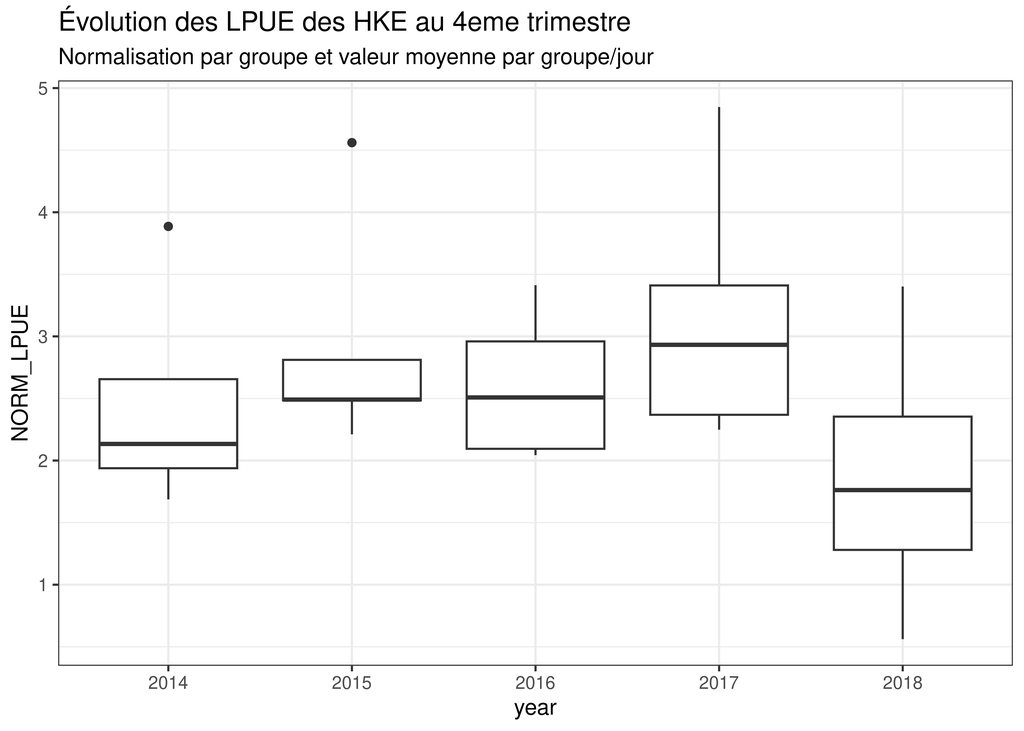

```r
indiv_effort |> ungroup() |>
  mutate(NORM_EFFORT = norm_indiv_effort) |>
  mutate(year = factor(year(time))) |>
  mutate(NORM_LPUE = LANDINGS/NORM_EFFORT) |>
  group_by(Group, year) |>
  summarise(NORM_LPUE = mean(NORM_LPUE)) |>
  ggplot(aes(x = year, y = NORM_LPUE)) +
  geom_boxplot() +
  theme_bw() +
  ggtitle("Évolution des LPUE des HKE au 4eme trimestre",
          subtitle = "Normalisation par groupe et valeur moyenne par groupe/jour")
```

Les évolutions relatives de la médiane sont de :

```r
indiv_effort |> ungroup() |>
  mutate(NORM_EFFORT = norm_indiv_effort) |>
  mutate(year = factor(year(time))) |>
  mutate(NORM_LPUE = LANDINGS/NORM_EFFORT) |>
  group_by(Group, year) |>
  summarise(NORM_LPUE = mean(NORM_LPUE)) |>
  ungroup() |>
  group_by(year) |>
  summarise(NORM_LPUE = median(NORM_LPUE)) |>
  mutate(NORM_LPUE = NORM_LPUE/NORM_LPUE[1])
```

```
# A tibble: 5 × 2
  year  NORM_LPUE
  <fct>     <dbl>
1 2014      1
2 2015      1.17
3 2016      1.18
4 2017      1.37
5 2018      0.826
```

Les résultats des LPUE relatives sont très différents de celle de l’estimateur naif.

```r
df_hke |>
  mutate(quarter = quarter(time), year = year(time)) |>
  filter(EFFORT >= 3) |>
  filter(quarter == 4) |>
  mutate(LPUE = LANDINGS/EFFORT) |>
  group_by(quarter, year) |>
  summarise(LPUE = median(LPUE)) |>
  mutate(REL_LPUE = LPUE/LPUE[1])
```

```
# A tibble: 5 × 4
# Groups:   quarter [1]
  quarter  year  LPUE REL_LPUE
    <int> <dbl> <dbl>    <dbl>
1       4  2014  1.63     1
2       4  2015  2.78     1.70
3       4  2016  2.25     1.38
4       4  2017  3.11     1.90
5       4  2018  1.69     1.03
```

### La cardine

```r
df_mnz <- df_sacrois_xgv_capt |> filter(ESP_COD_FAO == "MNZ") |>
  select(TP_NAVIRE_SACROIS, MAREE_ID, QUANT_POIDS_VIF_MOYENNE) |>
  group_by(MAREE_ID) |>
  summarise(LANDINGS = sum(QUANT_POIDS_VIF_MOYENNE),
            EFFORT = sum(TP_NAVIRE_SACROIS)) |>
  ungroup() |>
  rename(maree = MAREE_ID) |>
  left_join(df_cvae_group) |>
  mutate(year = factor(year(time)),
         Group = LETTERS[Group]) |>
  mutate(Group = factor(Group, levels = LETTERS[1:5])) |>
  na.omit() |>
  select(maree, time, navire, LANDINGS, EFFORT, Group)
```

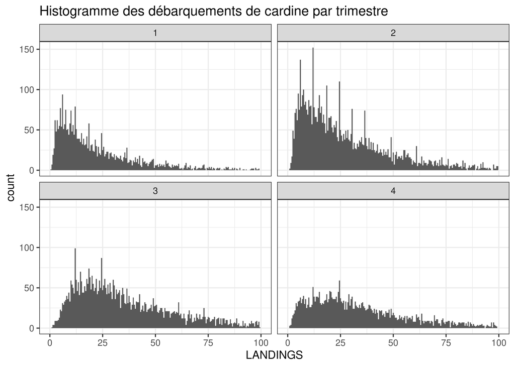

```r
df_mnz |>
  mutate(quarter = quarter(time)) |>
  ggplot(aes(x = LANDINGS)) +
  geom_histogram(binwidth = .5) +
  theme_bw() +
  facet_wrap(~ quarter) +
  xlim(0,100) +
  ggtitle("Histogramme des débarquements de cardine par trimestre")
```

[figure not shown]

```r
df_mnz|>
  mutate(quarter = quarter(time), year = year(time)) |>
  filter(EFFORT >= 3) |>
#  filter(quarter == 2) |>
  ggplot(aes(x = year, y = LANDINGS/EFFORT, group = year)) +
  geom_boxplot() +
  stat_summary(col = "blue") +
  theme_bw() +
  facet_wrap(~ quarter) +
  ylim(0,7) +
  ggtitle("Évolution des LPUE des HKE pour chaque trimestre (naive)")
```

Les évolutions relatives de la médiane sont de :

```r
df_mnz |>
  mutate(quarter = quarter(time), year = year(time)) |>
  filter(EFFORT >= 3) |>
#  filter(quarter == 2) |>
  mutate(LPUE = LANDINGS/EFFORT) |>
  group_by(quarter, year) |>
  summarise(LPUE = median(LPUE)) |>
  mutate(REL_LPUE = LPUE/LPUE[1])
```

```
# A tibble: 20 × 4
# Groups:   quarter [4]
   quarter  year  LPUE REL_LPUE
     <int> <dbl> <dbl>    <dbl>
 1       1  2014  1.15    1
 2       1  2015  2.41    2.09
 3       1  2016  1.53    1.32
 4       1  2017  1.73    1.50
 5       1  2018  3.63    3.15
 6       2  2014  3.03    1
 7       2  2015  2.32    0.765
 8       2  2016  2.37    0.781
 9       2  2017  2.17    0.717
10       2  2018  1.96    0.648
11       3  2014  4.54    1
12       3  2015  3.67    0.807
13       3  2016  2.99    0.659
14       3  2017  3.66    0.805
15       3  2018  2.45    0.539
16       4  2014  3.77    1
17       4  2015  3.45    0.914
18       4  2016  3.98    1.05
19       4  2017  3.50    0.927
20       4  2018  2.30    0.609
```

Les LPUE augmentent au premier trimestre et decroient aux autres trimestres.

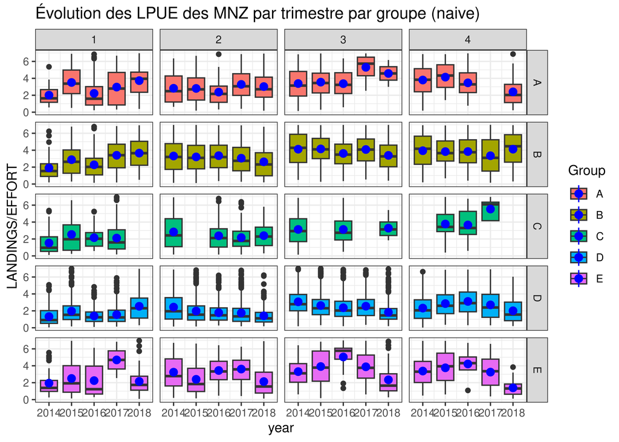

```r
df_mnz |>
  mutate(quarter = quarter(time), year = year(time)) |>
  filter(EFFORT >= 3) |>
 # filter(quarter == 2) |>
  ggplot(aes(x = year, y = LANDINGS/EFFORT, group = year, fill = Group)) +
  geom_boxplot() +
  theme_bw() +
  stat_summary(col = "blue", fun = "mean") +
  facet_grid(Group ~ quarter) +
  ylim(0,7) +
  ggtitle("Évolution des LPUE des MNZ par trimestre par groupe (naive)")
```

On se concentre sur le quatrième trimestre pour l’évaluation des LPUE avec effort normalisé. Certaines campagnes scientifiques sont menés en fin d’année à partir d’octobre.

```r
group_effort <- df_mnz |>
  group_by(Group, time) |>
  filter(quarter(time) == 4) |>
  summarise(EFFORT = mean(EFFORT))
unique_navire <- df_mnz |> filter(quarter(time) == 4) |> pull(navire) |> unique()
unique_date <- df_mnz |> filter(quarter(time) == 4) |> pull(time) |> unique()
unique_group <- df_mnz |> filter(quarter(time) == 4) |> pull(Group) |> unique()
maree <- df_mnz |> filter(quarter(time) == 4) |> pull(maree) |> unique()
indiv_effort <-
  df_mnz |>
  filter(quarter(time) == 4)
norm_indiv_effort <-
 sapply(seq_along(maree),
       function(m) {
         df <- indiv_effort[m,]
         geff <- group_effort |> filter(time == df$time)
         mean(geff$EFFORT*iidcolsbm_trim$alpha[df$Group, geff$Group] +
           (1-iidcolsbm_trim$alpha[df$Group, geff$Group])*df$EFFORT)
       })
```

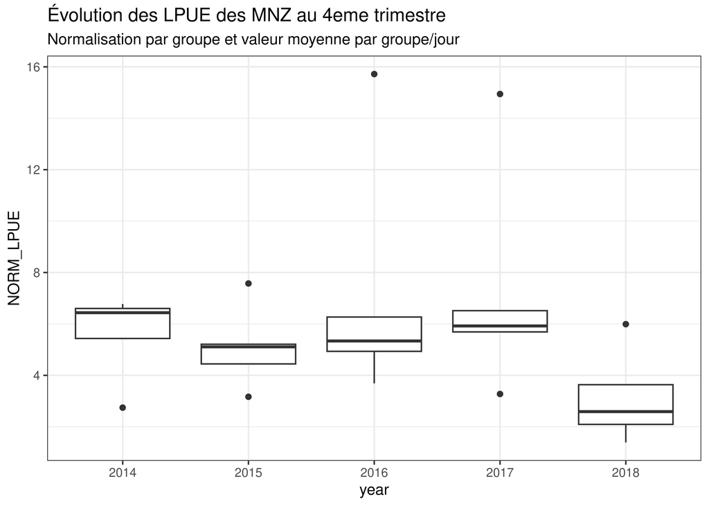

```r
indiv_effort |> ungroup() |>
  mutate(NORM_EFFORT = norm_indiv_effort) |>
  mutate(year = factor(year(time))) |>
  mutate(NORM_LPUE = LANDINGS/NORM_EFFORT) |>
  group_by(Group, year) |>
  summarise(NORM_LPUE = mean(NORM_LPUE)) |>
  ggplot(aes(x = year, y = NORM_LPUE)) +
  geom_boxplot() +
  theme_bw() +
  ggtitle("Évolution des LPUE des MNZ au 4eme trimestre",
          subtitle = "Normalisation par groupe et valeur moyenne par groupe/jour")
```

Les évolutions relatives de la médiane sont de :

```r
indiv_effort |> ungroup() |>
  mutate(NORM_EFFORT = norm_indiv_effort) |>
  mutate(year = factor(year(time))) |>
  mutate(NORM_LPUE = LANDINGS/NORM_EFFORT) |>
  group_by(Group, year) |>
  summarise(NORM_LPUE = mean(NORM_LPUE)) |>
  ungroup() |>
  group_by(year) |>
  summarise(NORM_LPUE = median(NORM_LPUE)) |>
  mutate(NORM_LPUE = NORM_LPUE/NORM_LPUE[1])
```

```
# A tibble: 5 × 2
  year  NORM_LPUE
  <fct>     <dbl>
1 2014      1
2 2015      0.794
3 2016      0.829
4 2017      0.920
5 2018      0.402
```

Les résultats des LPUE relatives changent un peu, mais on observe la même chutte entre 2017 et 2018. De manière intéressante, cette chutte n’est pas observé pour le groupe $B$ qui voient même ces LPUE augmentaient par rapport à 2017.

```r
df_mnz |>
  mutate(quarter = quarter(time), year = year(time)) |>
  filter(EFFORT >= 3) |>
  filter(quarter == 4) |>
  mutate(LPUE = LANDINGS/EFFORT) |>
  group_by(quarter, year) |>
  summarise(LPUE = median(LPUE)) |>
  mutate(REL_LPUE = LPUE/LPUE[1])
```

```
# A tibble: 5 × 4
# Groups:   quarter [1]
  quarter  year  LPUE REL_LPUE
    <int> <dbl> <dbl>    <dbl>
1       4  2014  3.77    1
2       4  2015  3.45    0.914
3       4  2016  3.98    1.05
4       4  2017  3.50    0.927
5       4  2018  2.30    0.609
```